[OHI-Northeast](http://www.ohi-northeast.org/) | [OHI Science](http://ohi-science.org) | [Citation policy](http://ohi-science.org/citation-policy/)

# OHI-Northeast: Sea Level Rise Pressure Layer

Compiled on Mon Oct 7 12:50:51 2019 by verstaen

# Summary

# Data Source

**Reference**: AVISO [Monthly mean Maps of Sea Level Anomaly](http://www.aviso.altimetry.fr/en/data/products/sea-surface-height-products/global/msla-mean-climatology.html#c10358)

**Downloaded**: September 16, 2019

**Description**: Mean Sea Level Anomaly (m above a climatological mean)

**Native data resolution**: 0.25 degree cells

**Format**: NetCDF

# Setup

```r
knitr::opts_chunk$set(fig.width = 10, fig.height = 8, fig.path = 'figs/', message = FALSE, warning = FALSE)

source('~/github/ne-prep/src/R/common.R')  ### an OHI-NE specific version of common.R

library(raster)
library(tidyverse)
library(sf)
library(RColorBrewer)
library(googleVis)
library(foreach)
library(doParallel)
library(fasterize)
library(rasterVis)
library(animation)
```

```r
## define paths and variables to use throughout data prep
dir_git <- '~/github/ne-prep' #path to the ne-prep github directory
dir_anx <- file.path(dir_M, 'git-annex/neprep') #path to the nceas server where a the bigger files are kept/saved

cols <- rev(colorRampPalette(brewer.pal(9, "Spectral"))(255))
```

# Load Data

**Loading in SLR data files**

We don’t need to download the data from the website because it’s already been downloaded for the most recent year of global. So we can just grab the NetCDF files from the global folder.

```r
## d2016/msla_monthly_mean has data for 1993-2015
## then include list.files for d2017 through the data folder for current scenario year
nc_files <- c(list.files(file.path(dir_M, "git-annex/globalprep/_raw_data/AVISO_slr/d2019"),
                       full.names = TRUE, pattern = ".nc"),
              list.files(file.path(dir_M, "git-annex/globalprep/_raw_data/AVISO_slr/d2018"),
                       full.names = TRUE, pattern = ".nc"),
              list.files(file.path(dir_M, "git-annex/globalprep/_raw_data/AVISO_slr/d2017"),
                       full.names = TRUE, pattern = ".nc"),
              list.files(file.path(dir_M, "git-annex/globalprep/_raw_data/AVISO_slr/d2016/msla_monthly_mean"),
                      full.names = TRUE, pattern = ".nc"))

nc_files <- nc_files[-1:-2] # double check this, but it since the first two files are zip files I am confident in removing them. However, I did grab it directly from the most recent version of global so I so still want to make sure it's correct
```

A peak into what the monthly data looks like

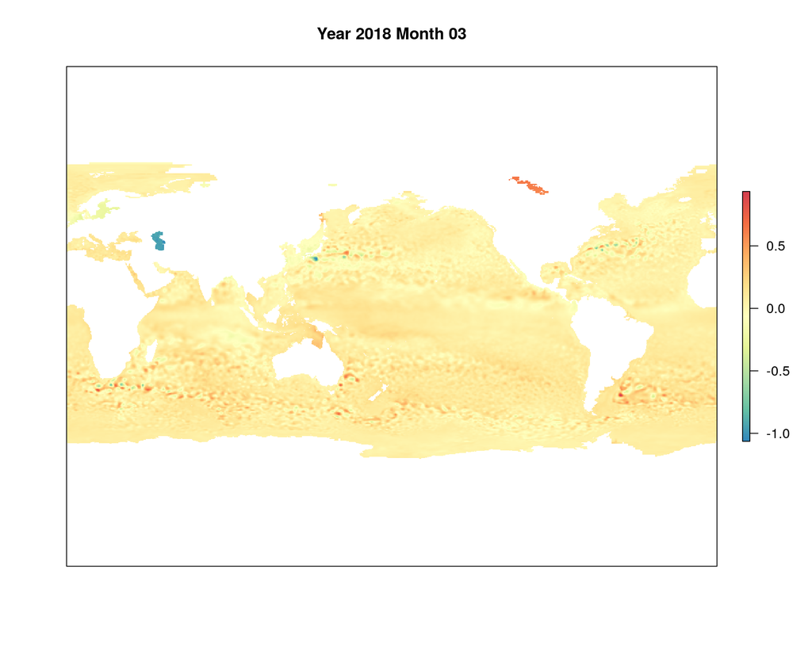

```r
plot(raster(nc_files[3]), col = cols, axes = F,
     main = paste("Year", substr(nc_files[3], 90, 93), "Month", substr(nc_files[3], 96, 97)))
```

# Convert .tif files into usable rasters

The following code is used to:

1. Rasterize each monthly NetCDF file
2. Rotate each raster so that the Atlantic Ocean is centered in the raster, and changes the extent from 0 to 360 to -180 to 180, which is needed when using wgs or us_albers projections/extents

```r
registerDoParallel(10)
## parallel forloop function that rotates each monthly file, sets the long/lat projection, and keeps only coastal cells - saved to GitHub

foreach(file = nc_files) %dopar% {

  m_yr <- substr(file, nchar(file)-10, nchar(file)-3)

  ## read in month raster
  r <- raster(file) %>%
    rotate()

  ## define projection of the raster before reprojecting; double check projection (USA Contiguous albers equal area)

  r <- raster::crop(r, wgs_ext)

  ## write raster to int folder in prs_slr
  fp <- sprintf("%s/int/msla_monthly/msla_monthly_%s.tif", file.path(dir_anx, "prs_slr"), m_yr)
  writeRaster(r, filename = fp, overwrite = TRUE)
}
```

# Calculate annual mean sea level anomalies

Annual mean sea level anomaly rasters are calculated from the monthly data.

```r
msla_files <- list.files(sprintf("%s/int/msla_monthly", file.path(dir_anx, "prs_slr")),
                         full.names = TRUE)
maxyr <- substr(msla_files, 73, 76) %>% as.numeric() %>% max()

## stack all rasters for this year, and calc annual mean, then write as raster
registerDoParallel(6)
foreach(yr = c(1993:maxyr)) %dopar% {

  files <- msla_files[str_detect(msla_files, as.character(yr))]

  rast_annual_mean <- stack(files) %>%
    calc(mean, na.rm = TRUE) %>%
    writeRaster(filename = sprintf("%s/int/msla_annual_mean/msla_annual_%s.tif", file.path(dir_anx, "prs_slr"), yr),
                overwrite = TRUE)
}
```

# Change the projection and mask

Since we are only interested in the increase in sea level near the coasts, we apply a mask to the raster layers that removes all cells farther than 3nm offshore. This mask was created previously for another part of this assessment

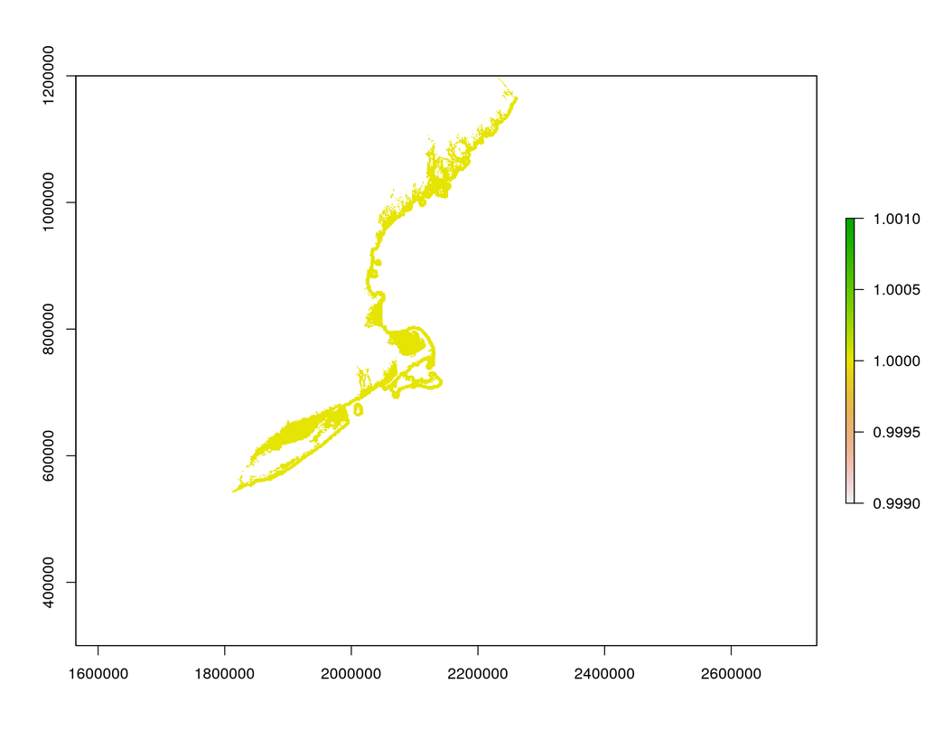

```r
three_nm <- raster(file.path(dir_git, "spatial/ocean_rasters/rast_3nm_mask.tif"))
three_nm <- raster::crop(three_nm, ne_ext)
plot(three_nm)
```

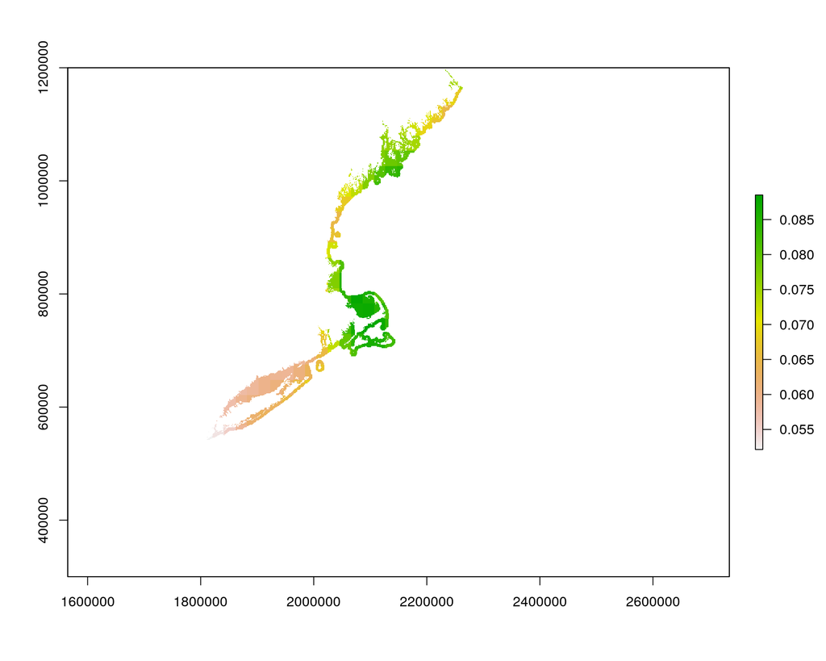

```r
#reproject means to us albers

annual_means <- list.files(file.path(dir_anx, "prs_slr/int/msla_annual_mean"), full = TRUE)
foreach(file = annual_means) %dopar% {

 # file = annual_means[26]
  yr <- str_sub(file, -8, -5)

  rast_data <- raster(file) %>%
    projectRaster(crs = us_alb, over = FALSE, progress="text") %>%
    raster::resample(three_nm, method = "ngb",
             filename = sprintf("%s/prs_slr/int/msla_annual_us_albers/mlsa_annual_us_albers_%s.tif",
                                dir_anx, yr), overwrite = TRUE) %>%
    mask(three_nm, filename = sprintf("%s/prs_slr/int/msla_annual_us_albers_coastal/msla_annual_us_albers_coastal_%s.tif", dir_anx, yr), overwrite = TRUE)
}

plot(raster(file.path(dir_anx, "prs_slr/int/msla_annual_us_albers_coastal/msla_annual_us_albers_coastal_2010.tif")))
```

# Reference Point

```r
coastal_rasts <- list.files(file.path(dir_anx, "prs_slr/int/msla_annual_us_albers_coastal"), pattern = "tif", full.names = TRUE)

registerDoParallel(8)

vals <- foreach(i = 1993:2017, .combine = c) %dopar% {

  i=2017
  coastal_rasts[which(str_sub(coastal_rasts, -8, -5) == i)] %>%
    raster() %>%
    getValues() %>%
    na.omit()

}

ref <- 1.1*max(vals)
```

The reference point is 0.093 meters.

# Rescale

We use the reference point to rescale all values from 0 to 1.

```r
registerDoParallel(10)

foreach(file = coastal_rasts) %dopar% { #file = coastal_rasts[10]
  yr <- str_sub(file, -8,-5)

    raster::raster(file) %>%
    calc(fun = function(x){ifelse(x < 0, 0, x)}) %>% # set all negative values to 0
    calc(fun = function(x){ifelse(x > ref, 1, x/ref)}, # set equal to one if greater than ref, otherwise scale
         filename = sprintf("%s/prs_slr/output/msla_rescaled/slr_%s.tif", dir_anx, yr), overwrite = TRUE)
}
```

# Results

```r
coastal_rasts <- list.files(file.path(dir_anx, 'prs_slr/output/msla_rescaled'), full.names = T) %>%
                           stack()

names(coastal_rasts) <- paste0("Year_", substr(names(coastal_rasts),5,8))

animation::saveGIF({
  for(i in 1:nlayers(coastal_rasts)){
     plot(ocean_ne,col='cornsilk2',  main=names(coastal_rasts[[i]]),axes=F,legend=F)
      # don't forget to fix the zlimits
    plot(coastal_rasts[[i]], zlim=c(0,1), axes=F, col=cols, add=T)

  }
}, movie.name = 'slr_annual_rescaled.gif')
```

```
## [1] TRUE
```

## Region scores

Extract data for each region

```r
# read in raster files
pressure_stack <- lapply(list.files(file.path(dir_anx, 'prs_slr/output/msla_rescaled'), full.names=T), raster) %>%
  brick()

# extract data for each region:
regions_stats <- zonal(pressure_stack,  zones, fun="mean", na.rm=TRUE, progress="text")
regions_stats2 <- data.frame(regions_stats)

data <- base::merge(rgn_data, regions_stats, all.y=TRUE, by.x="rgn_id", by.y="zone") %>%
          dplyr::select(-area_km2)%>%
  gather("year", "pressure_score",starts_with("slr_"))

slr_data <- data %>%
  mutate(year = substr(year, 5, 8)) %>%
  mutate(year = as.numeric(year))
```

```r
write.csv(slr_data, file.path("~/github/ne-scores/region/layers/cc_slr.csv"), row.names=FALSE)
```

## 2017 scores

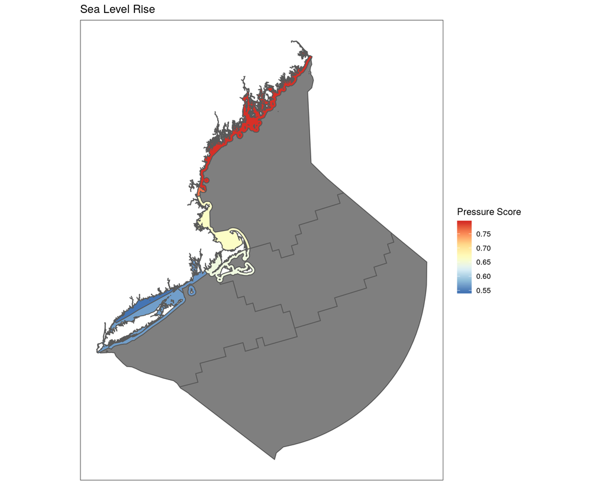

```r
last_year <- slr_data%>%
  filter(year==2017)

#map_scores is a function to plot a tmap map of the scores
map_scores(last_year, score_var = last_year$pressure_score, scale_label = "Pressure Score", map_title = "Sea Level Rise")
```

## Visualize through time

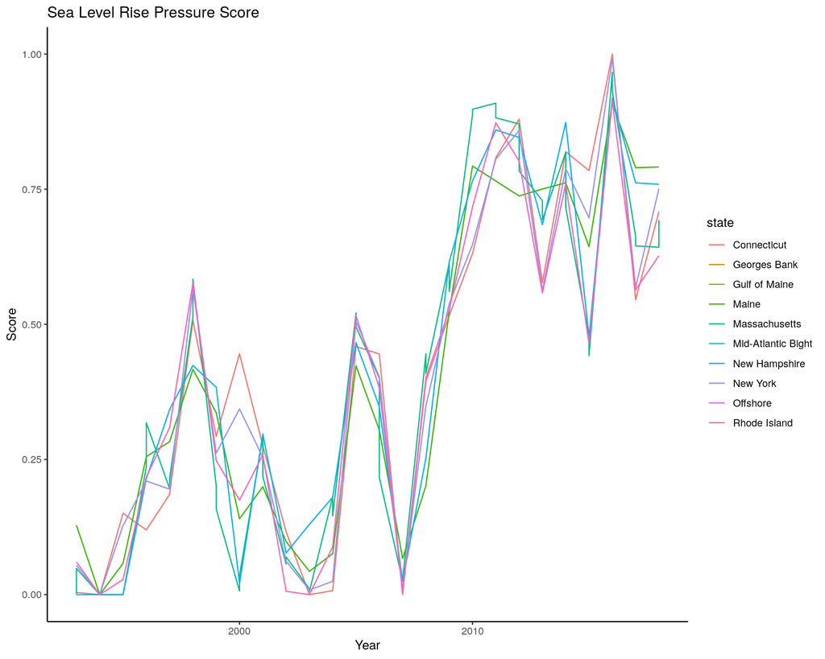

```r
slr_overtime <-ggplot(slr_data)+
  geom_line(aes(x=year, y = pressure_score, color=state))+
  ggtitle("Sea Level Rise Pressure Score") +
  ylab("Score") +
  xlab("Year") +
  theme_classic()
slr_overtime
```

```r
ggsave(file.path(dir_git, "prep/pressures/slr/figs/scores_2005-2017.png"), width=7, height=5, dpi=300)
```